GeoStat Lab · M12 · Raster, telerilevamento e morfometria

M12_N12 · Tessera

# Hillshade: cambiare luce senza cambiare terreno

5 blocchi R eseguiti1 grafico0 errori · 0 avvisiOffline · MathML

Codice, output e figure dello stesso svolgimento. Ogni notebook riparte dai dati locali ed è autonomo rispetto agli altri.

# La domanda

Cambiare la luce modifica il rilievo o soltanto la sua rappresentazione?

## Obiettivi

- Conservare pendenza e esposizione del terreno.
- Calcolare due illuminazioni con azimut opposti.
- Verificare la formula con il prodotto fra normale e luce.

**Prima di iniziare.** Sono richiesti vettori, matrici, tabelle e funzioni R di base. Eseguire i blocchi in ordine; ogni notebook è autonomo rispetto agli altri. I calcoli usano R base e i pacchetti standard.

**Dati e unità.** Il raster è interamente sintetico: 24 righe × 30 colonne, 720 celle quadrate di lato 30 m. Nel CSV riga e colonna partono da zero; x_m = 30 × colonna e y_m = 30 × riga indicano i centri nel piano locale. La riga 0 è a Sud; la riga 23 è a Nord. Le quote sono in metri sintetici. I dati non descrivono un rilievo reale.

**Relazione usata.** $I=\max(0,\mathbf n\cdot\mathbf l),\qquad \mathbf n=(-g_x,-g_y,1)/\sqrt{1+g_x^2+g_y^2}.$ La luce è un vettore unitario definito da azimut e altezza.

## Preparazione

Aprire il progetto autonomo di Tessera o quello generale dei notebook. I file originali restano invariati. Gli output vanno in `Risultati/M12_N12/`. Nessun download o installazione avviene nei blocchi.

Codice R · preparazione

```r
# Trova il modulo dal progetto autonomo o da quello generale dei notebook.
.gs_cerca <- normalizePath(getwd(),winslash="/",mustWork=TRUE)
repeat {
  .gs_candidati <- c(.gs_cerca,file.path(.gs_cerca,"M12_Tessera"),
    file.path(.gs_cerca,"03_Notebook_svolti","M12_Tessera"),
    file.path(.gs_cerca,"M12","03_Notebook_svolti","M12_Tessera"))
  .gs_ok <- file.exists(file.path(.gs_candidati,"M12_N01.Rmd")) &
    file.exists(file.path(.gs_candidati,"R","funzioni_notebook.R"))
  if(any(.gs_ok)) { .gs_modulo <- .gs_candidati[which(.gs_ok)[1L]];break }
  .gs_padre <- dirname(.gs_cerca)
  if(.gs_padre==.gs_cerca) stop("Aprire il progetto M12_Tessera o quello generale dei notebook.")
  .gs_cerca <- .gs_padre
}
source(file.path(.gs_modulo,"R","funzioni_notebook.R"),local=TRUE)
.gs_funzioni <- .gs_prepara_notebook(.gs_modulo,"M12_N12")
carica_dati <- .gs_funzioni$carica_dati
percorso_dati <- .gs_funzioni$percorso_dati
percorso_risultati <- .gs_funzioni$percorso_risultati
options(width=88,digits=6)
if(requireNamespace("knitr",quietly=TRUE)) {
  knitr::opts_chunk$set(echo=TRUE,error=FALSE,warning=TRUE,message=TRUE,
    fig.width=8,fig.height=5,dpi=150,fig.align="center")
}
set.seed(20261104)
```

## 1. La superficie rimane fissa

Usiamo le 616 celle interne e altezza solare di 45°. Cambia soltanto l’azimut della sorgente luminosa.

Codice R · passo_01

```r
d <- carica_dati("raster_v3.csv")
audit_raster(d)
d <- d[order(d$riga,d$colonna),]
Z <- matrice_quote(d)
 g <- gradienti_centrali(Z)
 h1 <- hillshade_esplicito(g$gx,g$gy,315,45)
 h2 <- hillshade_esplicito(g$gx,g$gy,135,45)
 risultato <- data.frame(azimut=c(315,135),altezza=45,media=c(mean(h1),mean(h2)),
   minimo=c(min(h1),min(h2)),massimo=c(max(h1),max(h2)))
 risultato
 stopifnot(identical(dim(h1),c(22L,28L)),all(h1>=0&h1<=1),all(h2>=0&h2<=1))
```

Output eseguito

```
  azimut altezza    media   minimo  massimo
1    315      45 0.698684 0.413665 0.923625
2    135      45 0.654281 0.369667 0.903815
```

**Lettura del risultato.** L’intensità modellata va da 0 a 1. Non è una nuova quota e non è una misura radiometrica osservata.

## 2. Una seconda formulazione verifica segni e assi

Il prodotto della normale unitaria con il vettore della luce deve coincidere con la formula basata su pendenza ed esposizione.

Codice R · passo_02

```r
errori <- vapply(c(315,135),function(az) {
  luce <- c(sin(az*pi/180)*cos(pi/4),cos(az*pi/180)*cos(pi/4),sin(pi/4))
  attesa <- (-g$gx*luce[1]-g$gy*luce[2]+luce[3])/sqrt(1+g$gx^2+g$gy^2)
  attesa[attesa<0] <- 0
  max(abs(hillshade_esplicito(g$gx,g$gy,az,45)-attesa))
},numeric(1))
data.frame(azimut=c(315,135),errore_massimo=errori)
stopifnot(all(errori<1e-12))
```

Output eseguito

```
  azimut errore_massimo
1    315    3.33067e-16
2    135    3.33067e-16
```

**Lettura del risultato.** Questo controllo protegge la convenzione dell’azimut. Il modello considera illuminazione locale; non calcola ombre portate da rilievi lontani.

## 3. Due luci, una scala di intensità comune

Le due carte usano la stessa scala 0–1, così la differenza dipende dall’illuminazione dichiarata.

Codice R · passo_03

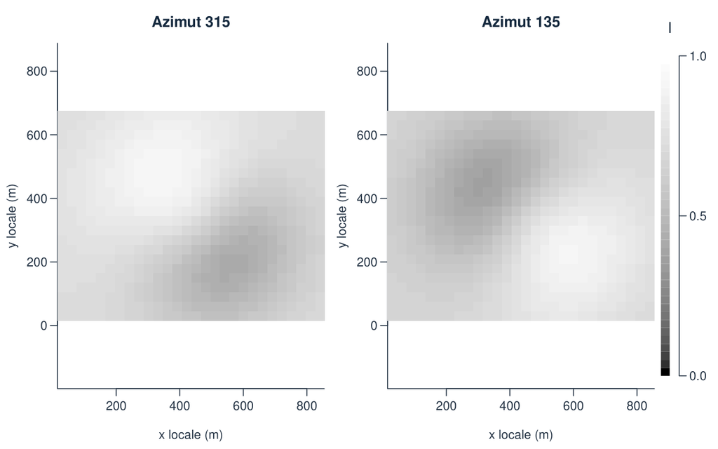

Figura 1 · Output del blocco `passo_03`. PDF vettoriale.

```r
op <- par(no.readonly=TRUE);layout(matrix(1:3,nrow=1),widths=c(4,4,.7))
for(k in 1:2) {
  stile_grafico();par(mar=c(4.2,4,3,.4),cex=.8)
  image((1:28)*30,(1:22)*30,t(list(h1,h2)[[k]]),asp=1,col=gray.colors(40,start=0,end=1),
    zlim=c(0,1),xlab="x locale (m)",ylab="y locale (m)",main=paste("Azimut",c(315,135)[k]),useRaster=TRUE)
}
par(mar=c(4.2,0,3,2.7));plot.new();plot.window(xlim=c(0,1),ylim=c(0,1))
br <- seq(0,1,length.out=41)
rect(0,head(br,-1),.5,tail(br,-1),col=gray.colors(40,start=0,end=1),border=NA)
axis(4,at=c(0,.5,1),las=1);mtext("I",side=3,line=.5)
layout(1);par(op)
write.csv(risultato,percorso_risultati("illuminazioni.csv"),row.names=FALSE)
```

**Lettura del risultato.** Il contrasto visivo può cambiare molto senza che il DEM cambi. Un hillshade non sostituisce legenda delle quote, orientamento o controlli del terreno.

## Variante svolta

**Cambiare anche l’altezza della luce.** Confrontare 20° e 70° mantenendo azimut 315° e verificare la stessa formulazione vettoriale.

Codice R · variante

```r
verifica <- lapply(c(20,70),function(alt) {
  h <- hillshade_esplicito(g$gx,g$gy,315,alt)
  luce <- c(sin(315*pi/180)*cos(alt*pi/180),cos(315*pi/180)*cos(alt*pi/180),sin(alt*pi/180))
  attesa <- (-g$gx*luce[1]-g$gy*luce[2]+luce[3])/sqrt(1+g$gx^2+g$gy^2)
  attesa[attesa<0] <- 0
  data.frame(altezza=alt,media=mean(h),errore=max(abs(h-attesa)))
})
verifica <- do.call(rbind,verifica);verifica
stopifnot(all(verifica$errore<1e-12))
```

Output eseguito

```
  altezza    media      errore
1      20 0.356730 4.99600e-16
2      70 0.909734 3.33067e-16
```

La prova con altezze diverse da 45° distingue correttamente seno e coseno dell’altezza luminosa.

## Errore da riconoscere

Interpretare i chiari e gli scuri come variazioni di quota o come una misura della riflettanza del terreno.

## Risposta alla domanda

L’hillshade è una rappresentazione condizionata a luce, convenzioni e modello di illuminazione. La topografia resta fissa; l’intensità cambia con azimut e altezza solare.

## Raccordo con le slide

Slide 69–71, 74, 76 della lezione Tessera. La mappa dei notebook e delle slide conserva il raccordo puntuale con la lezione estesa.

## Riferimenti e provenienza

Questo svolgimento sviluppa `M12_N12` del [modulo M12 del corso](https://marzione00.github.io/Lab_Geo/#modulo-M12). Il [codice originale](https://github.com/marzione00/Lab_Geo/blob/649f7cc577b96bd1044d81e78a2f530813e4f96b/materiali/laboratori/M12/M12_N12.R) è conservato immutato in `R/Originali_corso/`. Dati e originali hanno SHA-256 e SHA-1 Git verificati; gli ampliamenti sono dichiarati nella mappa degli originali.

Documentazione primaria delle operazioni: [R, matrix](https://stat.ethz.ch/R-manual/R-devel/library/base/html/matrix.html), [R, image](https://stat.ethz.ch/R-manual/R-devel/library/graphics/html/image.html), [R, quantile](https://stat.ethz.ch/R-manual/R-devel/library/stats/html/quantile.html). Le ipotesi e le convenzioni specifiche sono esplicitate nello svolgimento.